# Project Foundations for Data Science: FoodHub Data Analysis

**Marks: 60**

### Context

The number of restaurants in New York is increasing day by day. Lots of students and busy professionals rely on those restaurants due to their hectic lifestyles. Online food delivery service is a great option for them. It provides them with good food from their favorite restaurants. A food aggregator company FoodHub offers access to multiple restaurants through a single smartphone app.

The app allows the restaurants to receive a direct online order from a customer. The app assigns a delivery person from the company to pick up the order after it is confirmed by the restaurant. The delivery person then uses the map to reach the restaurant and waits for the food package. Once the food package is handed over to the delivery person, he/she confirms the pick-up in the app and travels to the customer's location to deliver the food. The delivery person confirms the drop-off in the app after delivering the food package to the customer. The customer can rate the order in the app. The food aggregator earns money by collecting a fixed margin of the delivery order from the restaurants.

### Objective

The food aggregator company has stored the data of the different orders made by the registered customers in their online portal. They want to analyze the data to get a fair idea about the demand of different restaurants which will help them in enhancing their customer experience. Suppose you are hired as a Data Scientist in this company and the Data Science team has shared some of the key questions that need to be answered. Perform the data analysis to find answers to these questions that will help the company to improve the business.

### Data Description

The data contains the different data related to a food order. The detailed data dictionary is given below.

### Data Dictionary

- order_id: Unique ID of the order
- customer_id: ID of the customer who ordered the food
- restaurant_name: Name of the restaurant
- cuisine_type: Cuisine ordered by the customer
- cost: Cost of the order
- day_of_the_week: Indicates whether the order is placed on a weekday or weekend (The weekday is from Monday to Friday and the weekend is Saturday and Sunday)
- rating: Rating given by the customer out of 5
- food_preparation_time: Time (in minutes) taken by the restaurant to prepare the food. This is calculated by taking the difference between the timestamps of the restaurant's order confirmation and the delivery person's pick-up confirmation.
- delivery_time: Time (in minutes) taken by the delivery person to deliver the food package. This is calculated by taking the difference between the timestamps of the delivery person's pick-up confirmation and drop-off information

### Let us start by importing the required libraries

```python
# import libraries for data manipulation
import numpy as np
import pandas as pd

# import libraries for data visualization
import matplotlib.pyplot as plt
import seaborn as sns
%matplotlib inline

# import libraries for mounting drive and setting workdir
import os
from google.colab import drive

import warnings
warnings.filterwarnings("ignore")
```

### Set Working directory

```python
root_dir = "/content/drive/"
project_folder = "My Drive/MIT_2023/Statistics_for_dataScience/caseStudy_foodHub/"
working_dir = root_dir + project_folder

drive.mount(root_dir)

def create_and_set_working_directory(project_folder):
  if os.path.isdir(working_dir) == False:
    os.mkdir(working_dir)
    print(working_dir + ' did not exist but was created.')

  os.chdir(working_dir)
  print('\nYour working directory was changed to ' + working_dir)

create_and_set_working_directory(project_folder)
```

```
Your working directory was changed to /content/drive/My Drive/MIT_2023/Statistics_for_dataScience/caseStudy_foodHub/
```

### Understanding the structure of the data

```python
# read the data
df = pd.read_csv('foodhub_order.csv')

# Copy of the original dataframe as read in
df_og = df

# returns the first 5 rows
df.head()
```

|  | order_id | customer_id | restaurant_name | cuisine_type | cost_of_the_order | day_of_the_week | rating | food_preparation_time | delivery_time |
| --- | --- | --- | --- | --- | --- | --- | --- | --- | --- |
| 0 | 1477147 | 337525 | Hangawi | Korean | 30.75 | Weekend | Not given | 25 | 20 |
| 1 | 1477685 | 358141 | Blue Ribbon Sushi Izakaya | Japanese | 12.08 | Weekend | Not given | 25 | 23 |
| 2 | 1477070 | 66393 | Cafe Habana | Mexican | 12.23 | Weekday | 5 | 23 | 28 |
| 3 | 1477334 | 106968 | Blue Ribbon Fried Chicken | American | 29.20 | Weekend | 3 | 25 | 15 |
| 4 | 1478249 | 76942 | Dirty Bird to Go | American | 11.59 | Weekday | 4 | 25 | 24 |

#### Observations:

The DataFrame has 9 columns as mentioned in the Data Dictionary. Data in each row corresponds to the order placed by a customer.

### **Question 1:** How many rows and columns are present in the data? [0.5 mark]

```python
print("DF has %i rows and %i columns." % (df.shape[0], df.shape[1]))
```

```
DF has 1898 rows and 9 columns.
```

#### Observations:

The food hub dataframe has 1898 rows and 9 columns.

### **Question 2:** What are the datatypes of the different columns in the dataset? (The info() function can be used) [0.5 mark]

```python
print("Datframe column types: \n")
df_og.info()

# Change restaurant_name column to type string
df['restaurant_name']=df['restaurant_name'].astype('string')

# Change dtype to category fpr categorical columns
cat_col = ['cuisine_type', 'day_of_the_week']
#cat_col = ['cuisine_type', 'day_of_the_week', 'rating']
for column in cat_col:
    df[column]=df[column].astype('category')

# Replace "Not given" ratings with NaN
df = df.replace('Not given',np.NaN)

# Numpy array with NaN cannot assume tyep int64
# Work around from pandas v0.24 support
# https://pandas.pydata.org/pandas-docs/version/0.24/whatsnew/v0.24.0.html#optional-integer-na-support
rating = pd.Series(df['rating'], dtype='Int64')
df['rating']=rating
```

```
Datframe column types:

<class 'pandas.core.frame.DataFrame'>
RangeIndex: 1898 entries, 0 to 1897
Data columns (total 9 columns):
 #   Column                 Non-Null Count  Dtype
---  ------                 --------------  -----
 0   order_id               1898 non-null   int64
 1   customer_id            1898 non-null   int64
 2   restaurant_name        1898 non-null   object
 3   cuisine_type           1898 non-null   object
 4   cost_of_the_order      1898 non-null   float64
 5   day_of_the_week        1898 non-null   object
 6   rating                 1898 non-null   object
 7   food_preparation_time  1898 non-null   int64
 8   delivery_time          1898 non-null   int64
dtypes: float64(1), int64(4), object(4)
memory usage: 133.6+ KB
```

**The data types of each DF column have been appropriately set now.**

```python
# Redefined datatypes of columns
print("Dataframe column types after appropriate type conversion:\n")
df.info()
```

```
Dataframe column types after appropriate type conversion:

<class 'pandas.core.frame.DataFrame'>
RangeIndex: 1898 entries, 0 to 1897
Data columns (total 9 columns):
 #   Column                 Non-Null Count  Dtype
---  ------                 --------------  -----
 0   order_id               1898 non-null   int64
 1   customer_id            1898 non-null   int64
 2   restaurant_name        1898 non-null   string
 3   cuisine_type           1898 non-null   category
 4   cost_of_the_order      1898 non-null   float64
 5   day_of_the_week        1898 non-null   category
 6   rating                 1162 non-null   Int64
 7   food_preparation_time  1898 non-null   int64
 8   delivery_time          1898 non-null   int64
dtypes: Int64(1), category(2), float64(1), int64(4), string(1)
memory usage: 110.3 KB
```

#### Observations:

- order_id, customer_id, food_preparation_time and delivery_time are of the type integer.
- The cost_of_the_order is of float64 type.
- restaurant_name is called as an object type but should be string.
- cuisine_type and day_of_the_week are called as object type but should be categorical variables.
- rating is set to integer after dropping unrated "Not given" orders.

The data types for each column was appropriately set for further analysis.

### **Question 3:** Are there any missing values in the data? If yes, treat them using an appropriate method. [1 mark]

**Missing data check in Numerical columns**.

We see no obvious missing values in the original dataframe.  
However, 736/1898 orders had a "Not given" rating that is technically missing data.

Above, we converted "Not given" values in the rating columns to NaNs and dropped them if rating was analyzed. Ratings could be influenced by a multitude of factors like the taste of food, aesthetics of packing, delivery time and also customer preference. Hence, it is hard to reliably impute the ratings from median ratings alone.

```python
# Checking for missing values in all columns
df_clean=df.dropna()
pd.DataFrame({'original_missing_values' : df_og.isna().sum(),
              'treated_missing_values' : df.isna().sum()})
```

|  | original_missing_values | treated_missing_values |
| --- | --- | --- |
| order_id | 0 | 0 |
| customer_id | 0 | 0 |
| restaurant_name | 0 | 0 |
| cuisine_type | 0 | 0 |
| cost_of_the_order | 0 | 0 |
| day_of_the_week | 0 | 0 |
| rating | 0 | 736 |
| food_preparation_time | 0 | 0 |
| delivery_time | 0 | 0 |

**Missing data check in Categorical columns**

```python
# Checking for categories representing missing values in categorical columns
for column in cat_col:
    print(df[column].value_counts())
    print("-" * 50)
```

```
American          584
Japanese          470
Italian           298
Chinese           215
Mexican            77
Indian             73
Middle Eastern     49
Mediterranean      46
Thai               19
French             18
Southern           17
Korean             13
Spanish            12
Vietnamese          7
Name: cuisine_type, dtype: int64
--------------------------------------------------
Weekend    1351
Weekday     547
Name: day_of_the_week, dtype: int64
--------------------------------------------------
```

#### Observations:

Only the rating column had 736 "Not given" values which are the only missing values in this dataset.  
These values were converted to NaNs and the column dtype was set tp Int64 was further analysis.

### **Question 4:** Check the statistical summary of the data. What is the minimum, average, and maximum time it takes for food to be prepared once an order is placed? [2 marks]

**Statistical summary of numerical variables**

```python
# Statistical summary of numerical variables
df.describe().T
```

|  | count | mean | std | min | 25% | 50% | 75% | max |
| --- | --- | --- | --- | --- | --- | --- | --- | --- |
| order_id | 1898.0 | 1477495.5 | 548.049724 | 1476547.0 | 1477021.25 | 1477495.5 | 1477969.75 | 1478444.0 |
| customer_id | 1898.0 | 171168.478398 | 113698.139743 | 1311.0 | 77787.75 | 128600.0 | 270525.0 | 405334.0 |
| cost_of_the_order | 1898.0 | 16.498851 | 7.483812 | 4.47 | 12.08 | 14.14 | 22.2975 | 35.41 |
| rating | 1162.0 | 4.344234 | 0.741478 | 3.0 | 4.0 | 5.0 | 5.0 | 5.0 |
| food_preparation_time | 1898.0 | 27.37197 | 4.632481 | 20.0 | 23.0 | 27.0 | 31.0 | 35.0 |
| delivery_time | 1898.0 | 24.161749 | 4.972637 | 15.0 | 20.0 | 25.0 | 28.0 | 33.0 |

**Statistical summary of non-numerical variables**

```python
# Statistical summary of non-numerical variables
df.describe(exclude = 'number').T
```

|  | count | unique | top | freq |
| --- | --- | --- | --- | --- |
| restaurant_name | 1898 | 178 | Shake Shack | 219 |
| cuisine_type | 1898 | 14 | American | 584 |
| day_of_the_week | 1898 | 2 | Weekend | 1351 |

#### Observations:

**Food preparation takes an average of 27.37 minutes and can range anywhere between 20 to 35 minutes.**

### **Question 5:** How many orders are not rated? [1 mark]

```python
print("%i of %i orders ~ %.2f percent are not rated." % (df['rating'].isna().sum(), df['rating'].shape[0], (df['rating'].isna().sum()/df['rating'].shape[0])*100))
```

```
736 of 1898 orders ~ 38.78 percent are not rated.
```

#### Observations:

**736 (~38.78%) orders are not rated.**.  
We will be ignoring the ratings of these orders assuming them as NaNs.

### Exploratory Data Analysis (EDA)

### **Question 6:** Explore all the variables and provide observations on their distributions. (Generally, histograms, boxplots, countplots, etc. are used for univariate exploration.) [9 marks]

**Exploratory Histograms of numerical columns**

```
array([[<Axes: title={'center': 'cost_of_the_order'}>,
        <Axes: title={'center': 'food_preparation_time'}>],
       [<Axes: title={'center': 'delivery_time'}>,
        <Axes: title={'center': 'rating'}>]], dtype=object)
```

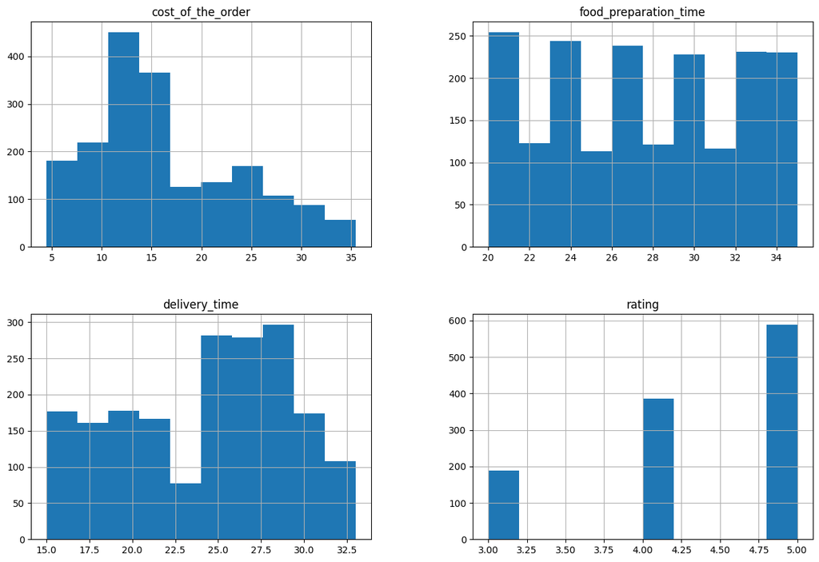

```python
univariate_continuous_cols=['cost_of_the_order', 'food_preparation_time', 'delivery_time']
univariate_discrete_cols=['rating']
univariate_categorical_cols=['cuisine_type', 'day_of_the_week']

df.loc[:,univariate_continuous_cols + univariate_discrete_cols].hist(figsize=(15,10))
```

#### Observations:

- Majority orders cost less than 20$.
- Food prepartion time appears more or less uniform.
- Food delivery time appears almost bimodal, could be influenced by other factors like the day of week.
- Majority of the food orders that received a rating have the highest rating of 5.

**Exploratory Boxplots of numerical columns**

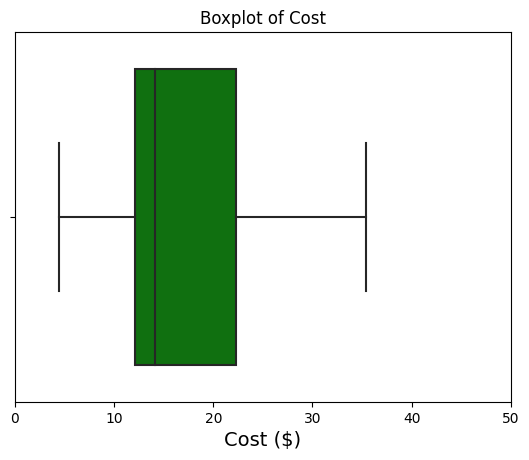

```python
plt.title('Boxplot of Cost')
sns.axes_style('whitegrid')
sns.boxplot(data=df, x='cost_of_the_order',color='green')
plt.xlim(0,50)
plt.xlabel("Cost ($)", size=14)
```

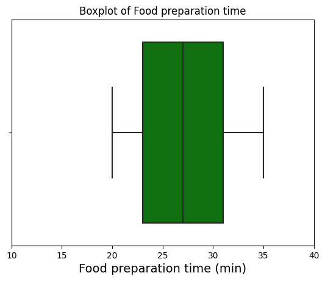

```python
plt.title('Boxplot of Food preparation time')
sns.axes_style('whitegrid')
sns.boxplot(data=df, x='food_preparation_time',color='green')
plt.xlim(10,40)
plt.xlabel("Food preparation time (min)", size=14)
```

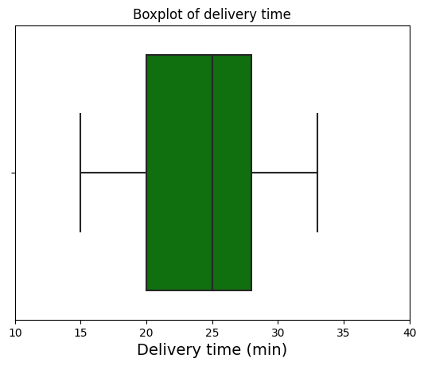

```python
plt.title('Boxplot of delivery time')
sns.axes_style('whitegrid')
sns.boxplot(data=df, x='delivery_time',color='green')
plt.xlim(10,40)
plt.xlabel("Delivery time (min)", size=14)
```

#### Observations:

- Cost appears to be right skewed with the median closer to the first quartile indicating that most orders appear to be moderately priced.
- Food preparation time has no skew and appears to be uniformly distributed.
- Delivery time is left skewed with the median closer to the third quartile indicating that in most cases delivery times can take longer than average.

**Exploratory countplots of categorical columns**

[output not shown]

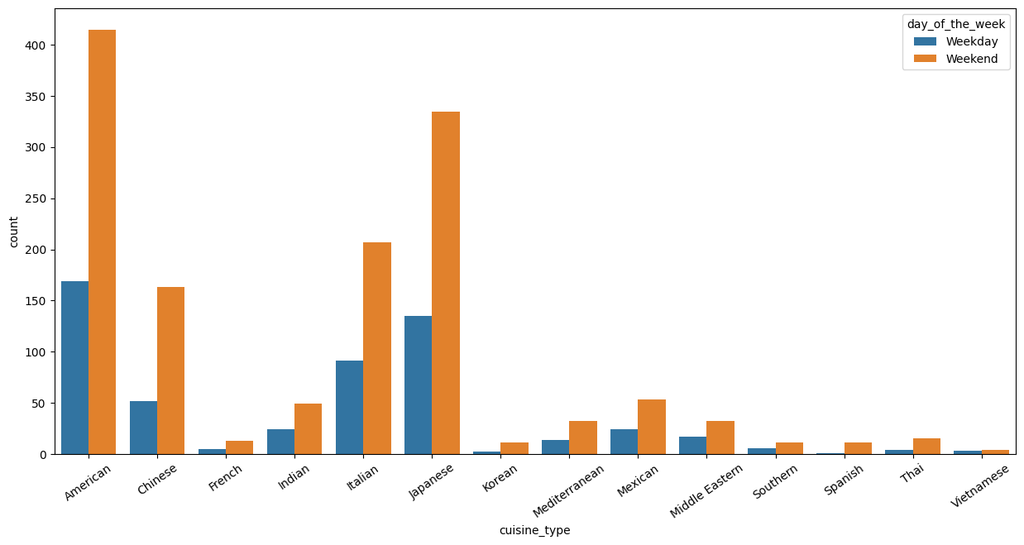

```python
plt.figure(figsize=(15,7))
sns.countplot(data=df, x='cuisine_type', hue='day_of_the_week')
plt.xticks(rotation=35)
```

#### Observations:

American Cuisine is a popular among customers while Korean and Vietnamese are not much desired by the customer base. For all cuisines, orders increase on weekends.

### **Question 7**: Which are the top 5 restaurants in terms of the number of orders received? [1 mark]

```python
top_restaurants_data = {'number_of_orders': df['restaurant_name'].value_counts()[0:5],
        'percentage_of_orders': round(df['restaurant_name'].value_counts(normalize=True)[0:5]*100,2)}

top_restaurants_df = pd.DataFrame(top_restaurants_data)

top_restaurants_df
```

|  | number_of_orders | percentage_of_orders |
| --- | --- | --- |
| Shake Shack | 219 | 11.54 |
| The Meatball Shop | 132 | 6.95 |
| Blue Ribbon Sushi | 119 | 6.27 |
| Blue Ribbon Fried Chicken | 96 | 5.06 |
| Parm | 68 | 3.58 |

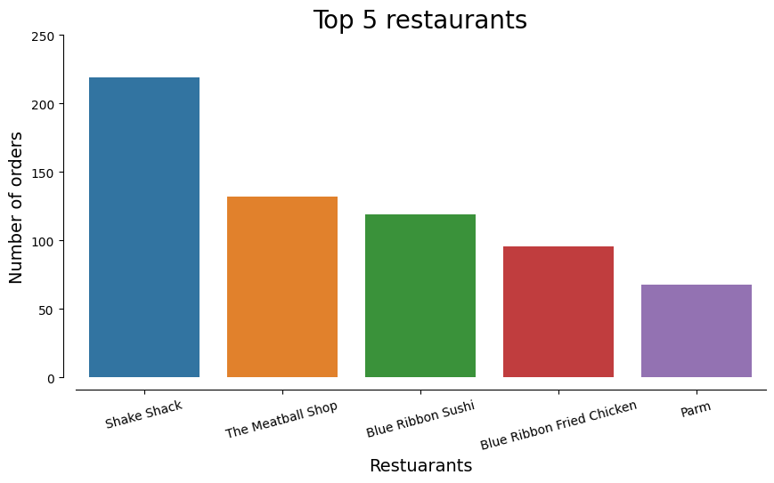

```python
plt.figure(figsize = (10, 5))
sns.barplot(data=top_restaurants_df, y='number_of_orders', x=top_restaurants_df.index)
sns.despine(offset=10)#, trim=True)
plt.ylim(0, 250)
plt.title('Top 5 restaurants', size=20)
plt.xlabel("Restuarants", size=14)
plt.ylabel("Number of orders", size=14)
plt.tick_params(axis='x', labelrotation=15)
```

```python
print("Together, the top 5 restaurants account for %.2f percent of the orders." % top_restaurants_df['percentage_of_orders'].sum())
```

```
Together, the top 5 restaurants account for 33.40 percent of the orders.
```

#### Observations:

We see that Shake Shack the top restaurant, leading with 11.5% of all orders.  
Together, the top 5 restaurants account for 33.40 percent of the orders.

### **Question 8**: Which is the most popular cuisine on weekends? [1 mark]

```python
weekend_df = df[df['day_of_the_week']=='Weekend']
weekend_orders = round(weekend_df['cuisine_type'].value_counts(normalize=True)*100,2)

popular_pct = pd.DataFrame({'cuisine' : weekend_orders.index,
                            'weekend_orders_percent' : np.array(weekend_orders)})
popular_pct
```

|  | cuisine | weekend_orders_percent |
| --- | --- | --- |
| 0 | American | 30.72 |
| 1 | Japanese | 24.80 |
| 2 | Italian | 15.32 |
| 3 | Chinese | 12.07 |
| 4 | Mexican | 3.92 |
| 5 | Indian | 3.63 |
| 6 | Mediterranean | 2.37 |
| 7 | Middle Eastern | 2.37 |
| 8 | Thai | 1.11 |
| 9 | French | 0.96 |
| 10 | Korean | 0.81 |
| 11 | Southern | 0.81 |
| 12 | Spanish | 0.81 |
| 13 | Vietnamese | 0.30 |

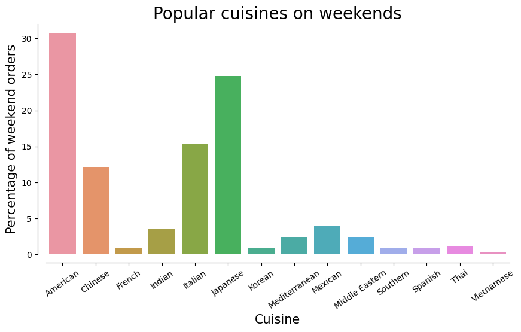

```python
plt.figure(figsize = (10, 5))
sns.barplot(data=popular_pct, y='weekend_orders_percent', x='cuisine')
sns.despine(offset=10) #, trim=True)
plt.ylim(0, 32)
plt.title('Popular cuisines on weekends', size=20)
plt.ylabel("Percentage of weekend orders", size=15)
plt.xlabel("Cuisine", size=15)
plt.tick_params(axis='x', labelrotation=35)
```

#### Observations:

**American cuisine is the most popular on weekends leading with 30.72% of all weekend orders.**

### **Question 9**: What percentage of the orders cost more than 20 dollars? [2 marks]

```python
cost_20=round((df[df['cost_of_the_order']>20].shape[0]/df.shape[0])*100,2)
print(cost_20,"% orders cost more than 20$.")
```

```
29.24 % orders cost more than 20$.
```

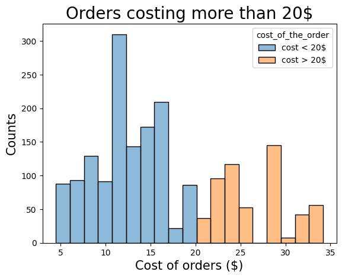

```python
cost_col = pd.cut(df['cost_of_the_order'], bins=[0, 20, 35], labels=['cost < 20$', 'cost > 20$'])
cost_20_plt = sns.histplot(data=df, x='cost_of_the_order', hue=cost_col)
plt.title("Orders costing more than 20$", size=20)
plt.xlabel("Cost of orders ($)", size=15)
plt.ylabel("Counts", size=15)
```

#### Observations:

**Almost a third of all orders cost more than 20$**.

### **Question 10**: What is the mean order delivery time? [1 mark]

```
The mean order delivery time is 24.16 minutes (red line).
```

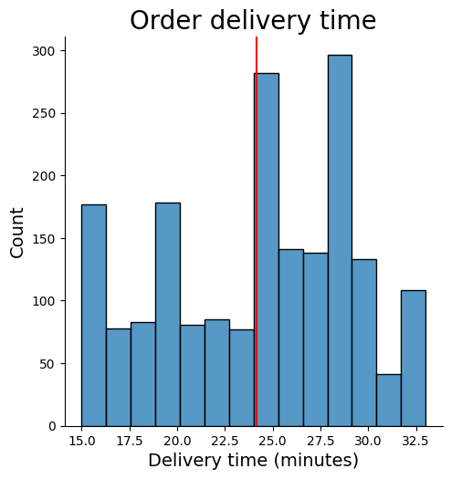

```python
print("The mean order delivery time is", round(df['delivery_time'].mean(),2), "minutes (red line).")
sns.displot(data=df, x='delivery_time')
plt.xlabel("Delivery time (minutes)", size=14)
plt.ylabel("Count", size=14)
plt.title("Order delivery time", size=20)
plt.axvline(x=df.delivery_time.mean(),
            color='red')
plt.show()
```

#### Observations:

**The mean delivery time takes around 24.16 minutes and can range anywhere between 15 to 33 minutes**.

### **Question 11:** The company has decided to give 20% discount vouchers to the top 3 most frequent customers. Find the IDs of these customers and the number of orders they placed. [1 mark]

```python
print("The company can award the 20% discount vouchers to the following people")
number_of_orders=df['customer_id'].value_counts()[0:3]
award_recipient_customer_ids=number_of_orders.index

recepients_data = {'discount_recipient_customer_ids': award_recipient_customer_ids,
    'number_of_orders': np.array(number_of_orders[0:3])}
recepients_df = pd.DataFrame(recepients_data, index=np.arange(1,4))
recepients_df
```

```
The company can award the 20% discount vouchers to the following people
```

|  | discount_recipient_customer_ids | number_of_orders |
| --- | --- | --- |
| 1 | 52832 | 13 |
| 2 | 47440 | 10 |
| 3 | 83287 | 9 |

#### Observations:

**The top 3 most frequent customers are in the table above and have atleast 9 orders or more**.

### **Question 12**: Perform a multivariate analysis to explore relationships between the important variables in the dataset. (It is a good idea to explore relations between numerical variables as well as relations between numerical and categorical variables) [10 marks]

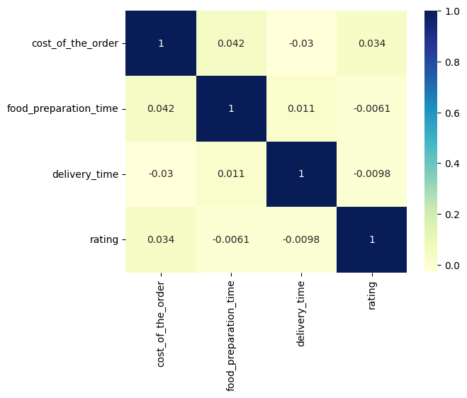

```python
sns.heatmap(data=df.loc[:,univariate_continuous_cols + univariate_discrete_cols].corr(), annot=True, cmap='YlGnBu');
```

- Ratings are slightly negatively correlated with preparation and delivery times.
- Cost of order is slightly negatively correlated with delivery times.
- All correlation appear very mild, no strong associations found.

[output not shown]

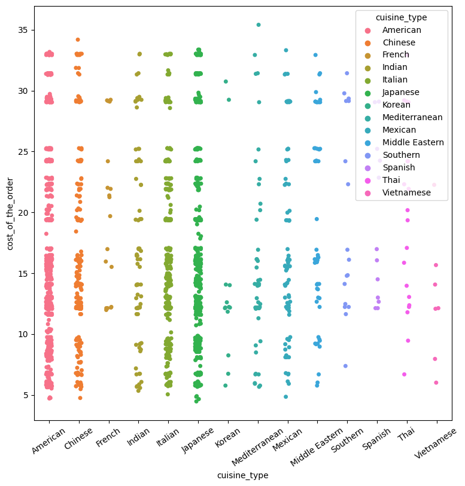

```python
plt.figure(figsize = (9, 9))
#sns.catplot(data=df, x="cuisine_type", y="cost_of_the_order", hue="cuisine_type", kind='swarm', palette='muted');
sns.stripplot(data=df, x="cuisine_type", y="cost_of_the_order", hue="cuisine_type", jitter=True)
plt.xticks(rotation=35)
```

- Cuisines are priced uniformly. There is not a very cheap or expensive cuisine to order.

### **Question 13:** The company wants to provide a promotional offer in the advertisement of the restaurants. The condition to get the offer is that the restaurants must have a rating count of more than 50 and the average rating should be greater than 4. Find the restaurants fulfilling the criteria to get the promotional offer. [3 marks]

```python
ratings_summary_df = pd.DataFrame({'rating_counts' : df.groupby('restaurant_name')['rating'].count(),
                                   'average_rating' : round(df.groupby('restaurant_name')['rating'].mean(),2)})

# Clean restaurant names of special charcters
ratings_summary_df['restaurant_name'] = ratings_summary_df.index.str.replace(r'\W', ' ', regex=True)

# Sort DF by avg ratings
ratings_summary_df.sort_values(by=['rating_counts','average_rating',], axis=0, ascending=[False, False], inplace=True, kind='quicksort', na_position='last')
#ratings_summary_df
```

```python
print("The following restaurants can be awarded the promotional offer in advertisements :\n")
promotional_offer_df=pd.DataFrame(ratings_summary_df.loc[(ratings_summary_df['rating_counts'] > 50) & (ratings_summary_df['average_rating'] > 4) , 'restaurant_name'])
promotional_offer_df.index = np.arange(1, len(promotional_offer_df) + 1)
promotional_offer_df

ratings_summary_df.head(4)
```

```
The following restaurants can be awarded the promotional offer in advertisements :
```

| restaurant_name | rating_counts | average_rating | restaurant_name |
| --- | --- | --- | --- |
| Shake Shack | 133 | 4.28 | Shake Shack |
| The Meatball Shop | 84 | 4.51 | The Meatball Shop |
| Blue Ribbon Sushi | 73 | 4.22 | Blue Ribbon Sushi |
| Blue Ribbon Fried Chicken | 64 | 4.33 | Blue Ribbon Fried Chicken |

```python
print("Of note, %i of %i restaurants never received a rating." % (ratings_summary_df['average_rating'].isna().sum(), ratings_summary_df.shape[0]))
```

```
Of note, 22 of 178 restaurants never received a rating.
```

#### Observations:

We have to note that 22/178 restaurants never received a rating from cutomers. Of the remaining, Shake Shack, The Meatball Shop, Blue Ribbon Sushi and Blue Ribbon Fried Chicken had atleast 50 orders and atleast an average rating of 4 and can hence be awarded rge promotional offer.

### **Question 14:** The company charges the restaurant 25% on the orders having cost greater than 20 dollars and 15% on the orders having cost greater than 5 dollars. Find the net revenue generated by the company across all orders. [3 marks]

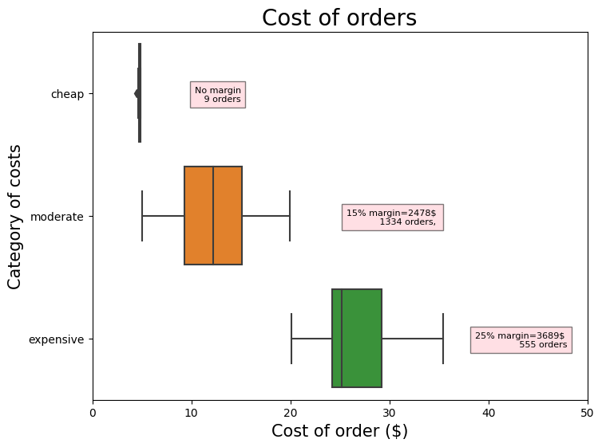

```python
cost_col2 = pd.cut(df['cost_of_the_order'], bins=[0, 5, 20, 36], labels=['cheap','moderate','expensive'])

#plt.title("Cost of orders", size=20)
#plt.xlabel("Cost of orders ($)", size=15)
#plt.ylabel("Counts", size=15)

plt.figure(figsize=(8, 6))
sns.boxplot(data=df, x="cost_of_the_order", y=cost_col2)
plt.title("Cost of orders", size=20)
plt.xlim(0,50)
plt.ylabel("Category of costs", size=15)
plt.xlabel("Cost of order ($)", size=15)

plt.text(15, 0.07,
         'No margin\n 9 orders',
         bbox=dict(facecolor='pink',
                   alpha=0.5),
         horizontalalignment='right',
         fontsize=8)

plt.text(35, 1.07,
         '15% margin=2478$ \n 1334 orders, ',
         bbox=dict(facecolor='pink',
                   alpha=0.5),
         horizontalalignment='right',
         fontsize=8)

plt.text(48, 2.07,
         '25% margin=3689$ \n 555 orders',
         bbox=dict(facecolor='pink',
                   alpha=0.5),
         horizontalalignment='right',
         fontsize=8)
```

```python
margin_df = df
margin_df['cost_category'] = cost_col2
total_revenue=np.array(margin_df.loc[margin_df['cost_category']== "expensive", 'cost_of_the_order']*0.25).sum() + np.array(margin_df.loc[margin_df['cost_category']== "moderate", 'cost_of_the_order']*0.15).sum()
print("Net revenue of company from all orders is %.2f $." % round(total_revenue,2))
```

```
Net revenue of company from all orders is 6166.30 $.
```

#### Observations:

A larger fraction of the orders cost between 5-20 dollars and generate an revenue of 2478 dollars.  
This is followed by orders that cost more than 20 dollars and generate a revenue of 3689 dollars.  
Together, they generate a total revenue of 6166.30 dollars.

### **Question 15:** The company wants to analyze the total time required to deliver the food. What percentage of orders take more than 60 minutes to get delivered from the time the order is placed? (The food has to be prepared and then delivered.) [2 marks]

```python
df['total_time'] = df['food_preparation_time'] + df['delivery_time']
total_time_60=round((df.loc[(df['total_time'] > 60), ['order_id']].shape[0]/df['order_id'].shape[0])*100,2)
print("%.2f percent orders take more than a total of 60 minutes to get delivered." % total_time_60)
```

```
10.54 percent orders take more than a total of 60 minutes to get delivered.
```

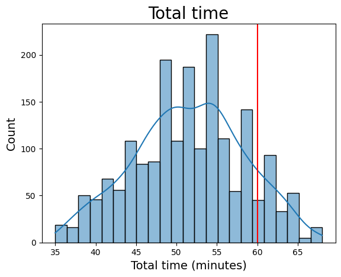

```python
sns.histplot(data=df, x='total_time', kde=True)
plt.xlabel("Total time (minutes)", size=14)
plt.ylabel("Count", size=14)
plt.title("Total time", size=20)
plt.axvline(x=60,
            color='red')
plt.show()
```

#### Observations:

Around 10.54% of all orders take more than 60 minutes to get delivered.  
We also see that the total delivery time is normally distributed and 60 minutes lies more closer towards the right tail of the distribution.

### **Question 16:** The company wants to analyze the delivery time of the orders on weekdays and weekends. How does the mean delivery time vary during weekdays and weekends? [2 marks]

```python
#pd.DataFrame({'mean_delivery_time' : np.array(df.groupby(by = ['day_of_the_week'])[['delivery_time']].mean()),
 #             'stdev_delivery_time' : np.array(df.groupby(by = ['day_of_the_week'])[['delivery_time']].std())})
df.groupby(by = ['day_of_the_week'])[['delivery_time']].mean()
```

| day_of_the_week | delivery_time |
| --- | --- |
| Weekday | 28.340037 |
| Weekend | 22.470022 |

[figure not shown]

```python
plt.figure(figsize = (5, 5))
sns.boxplot(x='day_of_the_week', y='delivery_time', data=df)
plt.ylabel('Delivery time (minutes)', size=15)
plt.xlabel('Day of week', size=15)
plt.title("Delivery time by day of the week\n", size=20)
plt.text(0.3, 29,
         '22.47 minutes',
         bbox=dict(facecolor='r',
                   alpha=0.5),
         horizontalalignment='right',
         fontsize=10)
plt.text(1.3, 23,
         '28.34 minutes',
         bbox=dict(facecolor='r',
                   alpha=0.5),
         horizontalalignment='right',
         fontsize=10)
plt.show()
```

#### Observations:

The mean delivery time on weekdays is longer than that on weekends by almost 6 minutes.  
Could probably be too much traffic on roads on weekdays with people commuting to work or more staff availability to deliver orders on weekends.  
Howvever, we also notice that the standard deviation of delivery time on weekends is higher than that of weekdays indicating a larger variation in the expected delivery time for customers. This could also be from satisfying a higher volume of orders on weekends than weekdays.

### Conclusion and Recommendations

### **Question 17:** What are your conclusions from the analysis? What recommendations would you like to share to help improve the business? (You can use cuisine type and feedback ratings to drive your business recommendations.) [6 marks]

#### Trying to understand the reason behind the 3 star ratings.

**Does total time taken to deliver order influence ratings?**

Mean total delivery time of all ratings appears more or less similar though 3 star ratings might take a few more seconds longer.  
Time is hence not impacting the ratings.

| rating | total_time |
| --- | --- |
| 3 | 51.989362 |
| 4 | 51.264249 |
| 5 | 51.568027 |

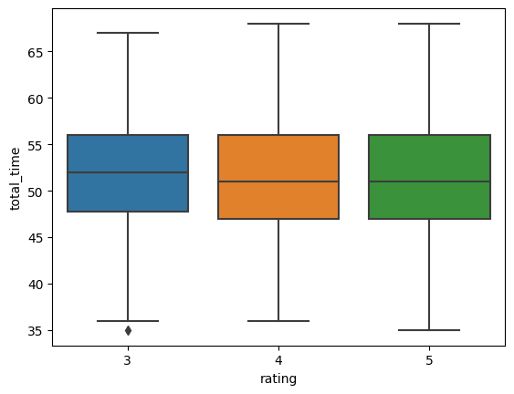

```python
df_clean=df.dropna()
sns.boxplot(x="rating", y="total_time", data=df_clean)
df.groupby(by = ['rating'])[['total_time']].mean()
```

**Does cuisine type impact the ratings?**

The cuisines adopt similar rating counts across the available rating categories. We do not see one particular cuisine that consistently rates bad. However, including more options from the popular American, Japanes and Italian cuisine can drive up ratings.

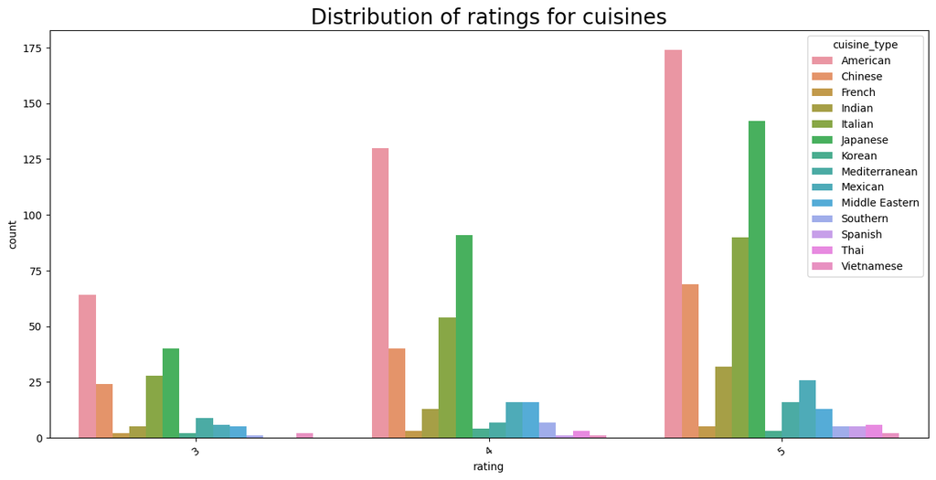

```python
plt.figure(figsize=(15,7))
sns.countplot(data=df_clean, hue='cuisine_type', x='rating')
plt.xticks(rotation=35)
plt.title("Distribution of ratings for cuisines", size=20)
```

```python
# Percent of orders for each cuisine
cuisine_orders = round(df['cuisine_type'].value_counts(normalize=True)*100,2)

# Percent of restaurants offering each cuisine
restaurant_cuisines = round((df.groupby(by = ['cuisine_type'])[['restaurant_name']].nunique()/df['restaurant_name'].nunique())*100,2)

# Median rating of each cuisine
average_rating_cuisine = df.groupby(by = ['cuisine_type'])[['rating']].median()

cuisines_df=pd.DataFrame({'percent_orders' : np.array(cuisine_orders),
                          'percent_restaurants' : np.array(restaurant_cuisines).flatten(),
                          'median_rating' : np.array(average_rating_cuisine).flatten(),
                          'cuisine' : cuisine_orders.index})
```

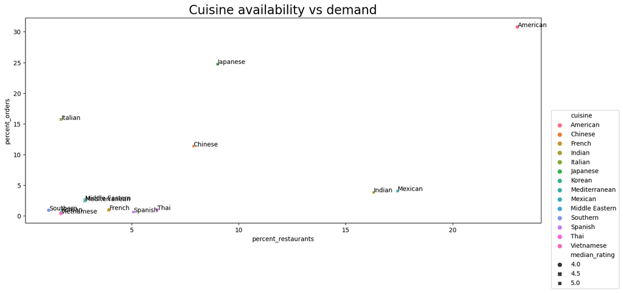

```python
plt.figure(figsize=(15,6))
sns.scatterplot(data=cuisines_df, x='percent_restaurants', y='percent_orders', hue='cuisine', style='median_rating')
plt.legend(bbox_to_anchor=(1.02, 0.55), loc='upper left', borderaxespad=0)
plt.title("Cuisine availability vs demand", size=20)

def label_point(x, y, val, ax):
    a = pd.concat({'x': x, 'y': y, 'val': val}, axis=1)
    for i, point in a.iterrows():
        ax.text(point['x']+.02, point['y'], str(point['val']))

label_point(cuisines_df.percent_restaurants, cuisines_df.percent_orders, cuisines_df.cuisine, plt.gca())
```

### Recommendations:

```python
!jupyter nbconvert --to html 'FDS_Project_LearnerNotebook_FullCode.ipynb'
```

```
[NbConvertApp] Converting notebook FDS_Project_LearnerNotebook_FullCode.ipynb to html
[NbConvertApp] Writing 1622304 bytes to FDS_Project_LearnerNotebook_FullCode.html
```